# Homework 4 - COVID-19 Study and Framingham Study

Group Member 1

Group Member 2

Group Member 3

Group Member 4

Group Member 5

Due: July 26 10pm

# 1 Case Study 1: COVID-19 Case Study

## 1.1 Background

The outbreak of the novel Corona virus disease 2019 (COVID-19) was declared a public health emergency of international concern by the World Health Organization (WHO) on January 30, 2020. Upwards of [112 million cases have been confirmed worldwide, with nearly 2.5 million associated deaths](https://covid19.who.int/). Within the US alone, there have been [over 500,000 deaths and upwards of 28 million cases reported](https://covid.cdc.gov/covid-data-tracker/#trends_dailytrendscases). Governments around the world have implemented and suggested a number of policies to lessen the spread of the pandemic, including mask-wearing requirements, travel restrictions, business and school closures, and even stay-at-home orders. The global pandemic has impacted the lives of individuals in countless ways, and though many countries have begun vaccinating individuals, the long-term impact of the virus remains unclear.

The impact of COVID-19 on a given segment of the population appears to vary drastically based on the socioeconomic characteristics of the segment. In particular, differing rates of infection and fatalities have been reported among different [racial groups](https://www.cdc.gov/coronavirus/2019-ncov/covid-data/investigations-discovery/hospitalization-death-by-race-ethnicity.html), [age groups](https://www.cdc.gov/coronavirus/2019-ncov/covid-data/investigations-discovery/hospitalization-death-by-age.html), and [socioeconomic groups](https://www.ncbi.nlm.nih.gov/pmc/articles/PMC7221360/). One of the most important metrics for determining the impact of the pandemic is the death rate, which is the proportion of people within the total population that die due to the the disease.

We assemble this dataset for our research with the goal to investigate the effectiveness of lockdown on flattening the COVID curve. We provide a portion of the cleaned dataset for this case study.

There are two main goals for this case study.

1. We show the development of COVID cases and COVID-related death at state level.
2. We try to figure out what county-level demographic and policy interventions are associated with mortality rate in the US. We try to construct models to find possible factors related to county-level COVID-19 mortality rates.

Remark: please keep track with the most updated version of this write-up.

## 1.2 Data Summary

The data comes from several different sources:

1. [County-level infection and fatality data](https://github.com/nytimes/covid-19-data) - This dataset gives daily cumulative numbers on infection and fatality for each county.
   - [NYC data](https://github.com/nychealth/coronavirus-data)
2. [County-level socioeconomic data](https://www.ers.usda.gov/data-products/atlas-of-rural-and-small-town-america/download-the-data/) - The following are the four relevant datasets from this site.
   1. Income - Poverty level and household income.
   2. Jobs - Employment type, rate, and change.
   3. People - Population size, density, education level, race, age, household size, and migration rates.
   4. County Classifications - Type of county (rural or urban on a rural-urban continuum scale).
3. [Intervention Policy Data](https://github.com/JieYingWu/COVID-19_US_County-level_Summaries/blob/master/data/interventions.csv) - This dataset is a manually compiled list of the dates that interventions/lockdown policies were implemented and lifted at the county level.

## 1.3 Two Main Datasets

In this case study, we use the following two cleaned data:

- **covid_county.csv**: County-level socioeconomic information that combines the above-mentioned 4 datasets: Income (Poverty level and household income), Jobs (Employment type, rate, and change), People (Population size, density, education level, race, age, household size, and migration rates), County Classifications
- **covid_rates.csv**: Daily cumulative numbers on infection and fatality for each county

Among all data, the unique identifier of county is `FIPS`.

First read in the data.

The detailed description of variables is in `Appendix: Data description`. Please get familiar with the variables.

```r
## county-level socioeconomic information
county_data <- fread("data/covid_county.csv")
## county-level COVID case and death
covid_rate <- fread("data/covid_rates.csv")
```

## 1.4 COVID death trend (Homework: question **i-vi**)

1. For each month in 2020, plot the monthly deaths per 100k heatmap by state on US map. Use the same color range across months. (Hints: Set `limits` argument in `scale_fill_gradient()` to fix the color scale. Use `facet_wrap()` to plot by month.)

**Important Remark**:

```r
## get daily new death
daily_death <- covid_rate %>%
  group_by(FIPS) %>%
  arrange(date) %>%
  mutate(daily_new_death = cum_deaths - lag(cum_deaths, default = 0))

## get monthly new death by state
covid_monthly <- daily_death %>%
  mutate(month = month(date),
         year = year(date)) %>%
  filter(year == 2020) %>%
  group_by(month, State) %>%
  summarize(daily_death = sum(daily_new_death))
## get state population
pop_state <- covid_rate %>%
  distinct(FIPS, State, TotalPopEst2019) %>%
  group_by(State) %>%
  summarize(population = sum(TotalPopEst2019, na.rm = T))

## join state monthly death with state population
covid_monthly <- merge(covid_monthly,
                       pop_state,
                       by = "State")

## get monthly new_death_per100k by state
covid_monthly <- covid_monthly %>%
  mutate(new_death_per100k = daily_death / population * 1e5)

## change State to state so that usmap recognizes
covid_monthly <- covid_monthly %>% rename(state = State)
```

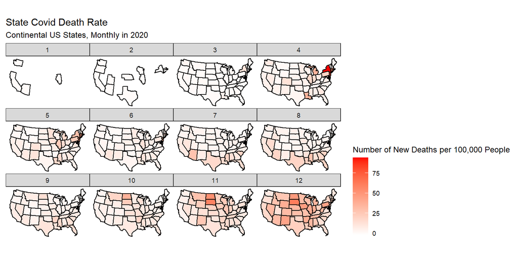

```r
library(usmap)

covid_monthly.plot <- plot_usmap(regions = "state",
                              #regions = "counties", for county level summary
    data = covid_monthly,
    values = "new_death_per100k", exclude = c("Hawaii", "Alaska"), color = "black") +
    scale_fill_gradient(
      low = "white", high = "red",
      name = "Number of New Deaths per 100,000 People",
      label = scales::comma) +
    labs(title = "State Covid Death Rate", subtitle = "Continental US States, Monthly in 2020") +
    theme(legend.position = "right") +
    facet_wrap(~ month)

covid_monthly.plot
```

## 1.5 COVID factor

We now try to build a good parsimonious model to find possible factors related to death rate on county level. Let us not take time series into account for the moment and use the total number as of *Feb 1, 2021*. (Hint: use `dplyr::filter()`.)

2. Create the response variable `total_death_per100k` as the total of number of COVID deaths per 100k by *Feb 1, 2021*. We suggest to take log transformation as `log_total_death_per100k = log(total_death_per100k + 1)`. Merge `total_death_per100k` to `county_data` for the following analysis. (Hint: check the R function `dplyr::join()` or `data.table::merge()`)

```r
covid_county_0201 <- covid_rate %>%
  filter(date == "2021-02-01") %>%
  mutate(log_death_rate = log(cum_deaths/TotalPopEst2019 * 1e5 + 1) ) %>%
  select(FIPS, log_death_rate)

covid_county_0201 <- left_join(covid_county_0201,
                               county_data,
                               by = "FIPS")
```

3. Select possible variables in `county_data` as covariates. We provide `county_data_sub`, a subset variables from `county_data`, for you to get started. Please add any potential variables as you wish.

Report missing values in your final subset of variables. In the following analysis, you may ignore the missing values.

**answer:**  
We use the default selected variables as selected in the code chunk below.

4. Use LASSO to choose a parsimonious model with all available sensible county-level information. Let’s first prepare the data using the following chunk. Why we need to drop County and FIPS? Why we only have 48 state indicators in the `X` model matrix? (Note that we only include states in the mainland plus DC, so there are 49 states in the data.) We drop county and fips because we cant estimate for all coefficients as unknown parameters is larger than sample sizes. We only use 0 to 48 to get 49 states excluding Hawaii and Alaska.

```r
# we first drop NAs
covid_county_0201 <- covid_county_0201 %>% drop_na()

# we need to drop the County and FIPS columns too!!!
covid_county_0201 <- covid_county_0201 %>% select(-County, -FIPS)

# create a model matrix and response vector
X <- model.matrix(log_death_rate~., covid_county_0201)[,-1]
y <- covid_county_0201$log_death_rate
```

22. Use `cv.glmnet()` to perform LASSO and land on a parsimonious model. You can use `lambda.min`, `lambda.1se`, or any sensible $\lambda$. Follow the chunk below and use `set.seed(15)`. **Force in State** in the process using the `penalty.factor` argument in `cv.glmnet()`. Why we need to force in State?

To include the State in the model, we force in the state as a value of the penalty factor as an argument in the cv.glmnet. We need to force it in because we are trying to find the effect of the state’s action on COVID infection.

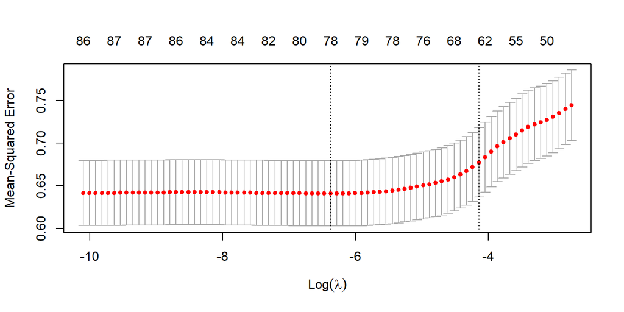

```r
# The `penalty.factor` argument in `cv.glmnet()` takes a vector of weights,
# each of which corresponds to one variable.
# 0 means no penalty/regularization or force in the variable, 1 means keeps the penalty/regularization
# Since the first 48 columns of X are the state indicators, the first 48 elements should be 0
# The rest should be 1 to keep the penalty.
state_ind <- c(rep(0, 48), rep(1, ncol(X)-48))

set.seed(15)

fit.cv <- cv.glmnet(X, y, alpha = 1, nfolds = 10, penalty.factor = state_ind)
plot(fit.cv)
```

```r
coeffs <- coef(fit.cv)
nonzeros <- rownames(as.matrix(coeffs[which(coeffs != 0), 0]))
non_state_intercept_coef <- nonzeros[50:length(nonzeros)]

select_cols <- c("State", "log_death_rate", non_state_intercept_coef)
lm_cols <- covid_county_0201 %>% select(select_cols)
```

```
## Note: Using an external vector in selections is ambiguous.
## i Use `all_of(select_cols)` instead of `select_cols` to silence this message.
## i See <https://tidyselect.r-lib.org/reference/faq-external-vector.html>.
```

```r
fit.lm <- lm(data = lm_cols, log_death_rate ~ .)
summary(fit.lm)
```

```
##
## Call:
## lm(formula = log_death_rate ~ ., data = lm_cols)
##
## Residuals:
##    Min     1Q Median     3Q    Max
## -5.796 -0.253  0.068  0.374  3.579
##
## Coefficients:
##                          Estimate Std. Error t value Pr(>|t|)
## (Intercept)              4.53e+00   4.17e-01   10.87  < 2e-16 ***
## StateAR                  5.57e-02   1.35e-01    0.41  0.67975
## StateAZ                  2.67e-01   2.38e-01    1.12  0.26188
## StateCA                 -7.71e-01   1.59e-01   -4.86  1.2e-06 ***
## StateCO                 -3.57e-01   1.53e-01   -2.34  0.01925 *
## StateCT                  1.78e-01   3.03e-01    0.59  0.55731
## StateDC                  5.20e-01   8.07e-01    0.64  0.51995
## StateDE                 -2.43e-02   4.69e-01   -0.05  0.95867
## StateFL                  3.11e-02   1.47e-01    0.21  0.83190
## StateGA                  6.59e-02   1.17e-01    0.57  0.57179
## StateIA                  2.87e-01   1.34e-01    2.15  0.03196 *
## StateID                 -3.22e-01   1.66e-01   -1.93  0.05336 .
## StateIL                  2.11e-01   1.32e-01    1.59  0.11188
## StateIN                 -7.37e-02   1.34e-01   -0.55  0.58119
## StateKS                 -6.28e-01   1.37e-01   -4.57  5.1e-06 ***
## StateKY                 -7.56e-01   1.28e-01   -5.90  4.1e-09 ***
## StateLA                  3.75e-01   1.43e-01    2.62  0.00879 **
## StateMA                  7.74e-02   2.40e-01    0.32  0.74734
## StateMD                 -5.88e-02   1.96e-01   -0.30  0.76450
## StateME                 -1.37e+00   2.25e-01   -6.09  1.3e-09 ***
## StateMI                 -1.47e-01   1.35e-01   -1.09  0.27753
## StateMN                 -1.57e-01   1.38e-01   -1.14  0.25376
## StateMO                 -3.78e-01   1.29e-01   -2.94  0.00330 **
## StateMS                  2.64e-01   1.32e-01    2.00  0.04559 *
## StateMT                  5.47e-01   1.58e-01    3.47  0.00053 ***
## StateNC                 -3.68e-01   1.27e-01   -2.91  0.00369 **
## StateND                  9.50e-01   1.66e-01    5.72  1.2e-08 ***
## StateNE                 -3.86e-01   1.43e-01   -2.71  0.00680 **
## StateNH                 -8.06e-01   2.73e-01   -2.95  0.00318 **
## StateNJ                  3.29e-01   2.09e-01    1.57  0.11553
```

[output cut: 26 more lines]

```
## Age65AndOlderPct2010     3.37e-02   7.65e-03    4.41  1.1e-05 ***
## Under18Pct2010           6.02e-02   7.83e-03    7.69  2.0e-14 ***
## Ed3SomeCollegePct       -2.09e-02   5.48e-03   -3.81  0.00014 ***
## Ed5CollegePlusPct       -1.15e-02   3.81e-03   -3.02  0.00256 **
## NetMigrationRate1019    -1.16e-02   2.56e-03   -4.53  6.1e-06 ***
## NaturalChangeRate1019   -4.41e-02   9.96e-03   -4.43  9.6e-06 ***
## WhiteNonHispanicPct2010 -2.86e-03   1.65e-03   -1.73  0.08371 .
## HispanicPct2010          8.81e-03   2.18e-03    4.05  5.3e-05 ***
## Type_2015_Update        -1.94e-02   8.62e-03   -2.25  0.02425 *
## ---
## Signif. codes:  0 '***' 0.001 '**' 0.01 '*' 0.05 '.' 0.1 ' ' 1
##
## Residual standard error: 0.79 on 3040 degrees of freedom
## Multiple R-squared:  0.359,  Adjusted R-squared:  0.345
## F-statistic: 26.6 on 64 and 3040 DF,  p-value: <2e-16
```

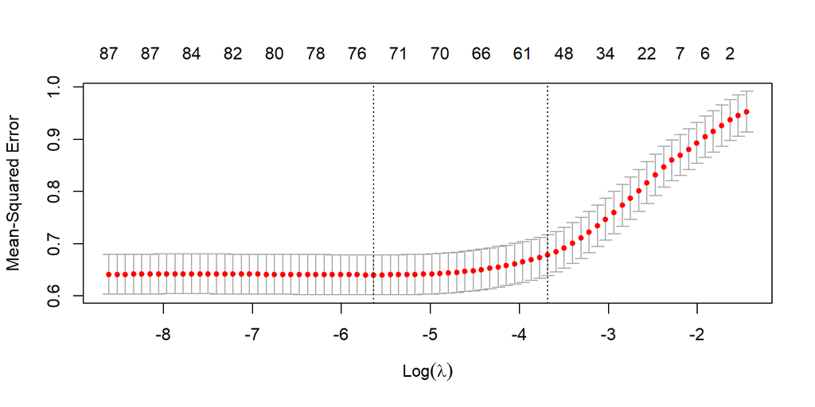

```r
#Another method using lambda.min and lambda.1se
# The `penalty.factor` argument in `cv.glmnet()` takes a vector of weights,
# each of which corresponds to one variable.
# 0 means no penalty/regularization or force in the variable, 1 means keeps the penalty/regularization
# Since the first 48 columns of X are the state indicators, the first 48 elements should be 0
# The rest should be 1 to keep the penalty.

library(glmnet)
state_ind <- c(rep(0, 48), rep(1, ncol(X)-48))
set.seed(15)
fit.force.cv <- cv.glmnet(X, y, alpha=1, nfolds=10,penalty_factor=state_ind)
 plot(fit.force.cv)
```

```r
# Now set seed then use `penalty.factor = state_ind` in `cv.glmnet()` to perform LAS
 #One may choose any lambda between lambda.min and lambda.1seO
 #one may also choose lambda controlled bynzero, the number ofnon-zero elements

coef.force.min <- coef(fit.force.cv, s="lambda.min")#s=c("lambda.1se","lambda.min") or lambda value
coef.force.min <- coef.force.min[which(coef.force.min !=0),]
coef.force.min
```

```
##                        (Intercept)                            StateAR
##                           3.95e+00                           1.33e-01
##                            StateAZ                            StateCA
##                           4.36e-01                          -5.27e-01
##                            StateCO                            StateCT
##                          -1.35e-01                           2.37e-01
##                            StateDC                            StateFL
##                           6.26e-01                           3.22e-02
##                            StateGA                            StateIA
##                           1.29e-01                           3.23e-01
##                            StateID                            StateIL
##                          -9.03e-02                           3.11e-01
##                            StateKS                            StateKY
##                          -5.21e-01                          -5.62e-01
##                            StateLA                            StateMA
##                           4.49e-01                           8.71e-02
##                            StateMD                            StateME
##                           3.47e-02                          -1.22e+00
##                            StateMO                            StateMS
##                          -2.66e-01                           4.68e-01
##                            StateMT                            StateNC
##                           6.67e-01                          -2.50e-01
##                            StateND                            StateNE
##                           9.59e-01                          -2.85e-01
##                            StateNH                            StateNJ
##                          -6.67e-01                           3.36e-01
##                            StateNM                            StateNV
##                          -3.28e-01                          -3.29e-01
##                            StateNY                            StateOH
##                          -2.38e-01                          -3.83e-01
##                            StateOK                            StateOR
##                          -2.99e-01                          -6.12e-01
##                            StatePA                            StateSD
##                           1.13e-01                           8.63e-01
##                            StateTN                            StateTX
##                           1.22e-01                           2.47e-01
##                            StateUT                            StateVA
##                          -7.54e-01                          -3.96e-01
##                            StateVT                            StateWA
##                          -1.97e+00                          -5.58e-01
```

[output cut: 21 more lines]

```
##                          -2.48e-02                          -1.39e-02
##                     ForeignBornPct               NetMigrationRate1019
##                           6.87e-03                          -1.27e-02
##              NaturalChangeRate1019            WhiteNonHispanicPct2010
##                          -4.36e-02                          -3.68e-03
##   NativeAmericanNonHispanicPct2010            AsianNonHispanicPct2010
##                           3.31e-03                           2.88e-03
##                    HispanicPct2010                   Type_2015_Update
##                           5.84e-03                          -9.42e-03
##        RuralUrbanContinuumCode2013                   Perpov_1980_0711
##                          -2.83e-02                          -1.31e-01
##                HiCreativeClass2000                          HiAmenity
##                          -5.33e-02                          -9.93e-02
## Retirement_Destination_2015_Update
##                           2.05e-03
```

```r
coef.force.1se <- coef(fit.force.cv, s="lambda.1se")
coef.force.1se <- coef.force.1se[which(coef.force.1se !=0),]# get the non=zero coefficients
coef.force.1se
```

```
##                 (Intercept)                     StateAR
##                     5.19679                     0.06365
##                     StateAZ                     StateCA
##                     0.20243                    -0.37307
##                     StateCO                     StateGA
##                    -0.06352                     0.03627
##                     StateIA                     StateIL
##                     0.30861                     0.25824
##                     StateKS                     StateKY
##                    -0.30230                    -0.45963
##                     StateLA                     StateME
##                     0.18169                    -0.86213
##                     StateMO                     StateMS
##                    -0.06741                     0.19806
##                     StateMT                     StateNC
##                     0.31769                    -0.11388
##                     StateND                     StateNE
##                     0.59858                    -0.14799
##                     StateNH                     StateNJ
##                    -0.22275                     0.23318
##                     StateNV                     StateOH
##                    -0.14740                    -0.18858
##                     StateOK                     StateOR
##                    -0.09366                    -0.46945
##                     StatePA                     StateSD
##                     0.04099                     0.63480
##                     StateTN                     StateTX
##                     0.07595                     0.28130
##                     StateUT                     StateVA
##                    -0.54240                    -0.24796
##                     StateVT                     StateWA
##                    -1.61845                    -0.51305
##                     StateWV           PovertyAllAgesPct
##                    -0.32432                     0.00541
##                  PctEmpFIRE          PctEmpConstruction
##                     0.01563                    -0.02589
##                 PctEmpTrade           PctEmpAgriculture
##                     0.00393                    -0.01930
##         PctEmpManufacturing        Age65AndOlderPct2010
##                     0.00901                     0.02384
##              Under18Pct2010           Ed3SomeCollegePct
##                     0.02467                    -0.02160
##           Ed5CollegePlusPct        NetMigrationRate1019
##                    -0.01476                    -0.00809
##       NaturalChangeRate1019     WhiteNonHispanicPct2010
##                    -0.01689                    -0.00652
##            Type_2015_Update RuralUrbanContinuumCode2013
##                    -0.01410                    -0.01458
##         HiCreativeClass2000                   HiAmenity
##                    -0.00302                    -0.03713
```

```r
var.min <- rownames(as.matrix(coef.force.min))[-1] # get all the NA values

 var.min
```

```
##  [1] "StateAR"                            "StateAZ"
##  [3] "StateCA"                            "StateCO"
##  [5] "StateCT"                            "StateDC"
##  [7] "StateFL"                            "StateGA"
##  [9] "StateIA"                            "StateID"
## [11] "StateIL"                            "StateKS"
## [13] "StateKY"                            "StateLA"
## [15] "StateMA"                            "StateMD"
## [17] "StateME"                            "StateMO"
## [19] "StateMS"                            "StateMT"
## [21] "StateNC"                            "StateND"
## [23] "StateNE"                            "StateNH"
## [25] "StateNJ"                            "StateNM"
## [27] "StateNV"                            "StateNY"
## [29] "StateOH"                            "StateOK"
```

[output cut: 22 more lines]

```r
 rownames(as.matrix(coef.force.min)) #output the names  dim(as.matrix(coef.min))
```

```
##  [1] "(Intercept)"                        "StateAR"
##  [3] "StateAZ"                            "StateCA"
##  [5] "StateCO"                            "StateCT"
##  [7] "StateDC"                            "StateFL"
##  [9] "StateGA"                            "StateIA"
## [11] "StateID"                            "StateIL"
## [13] "StateKS"                            "StateKY"
## [15] "StateLA"                            "StateMA"
## [17] "StateMD"                            "StateME"
## [19] "StateMO"                            "StateMS"
## [21] "StateMT"                            "StateNC"
## [23] "StateND"                            "StateNE"
## [25] "StateNH"                            "StateNJ"
## [27] "StateNM"                            "StateNV"
## [29] "StateNY"                            "StateOH"
```

[output cut: 23 more lines]

```r
len<-length(var.min) # total variables in var.min
len
```

```
## [1] 74
```

```r
var.min<-var.min[50:len] #remove StateXX and intercept from the variables
var.min
```

```
##  [1] "PctEmpTrade"                        "PctEmpInformation"
##  [3] "PctEmpAgriculture"                  "PctEmpManufacturing"
##  [5] "PctEmpServices"                     "PopDensity2010"
##  [7] "OwnHomePct"                         "Age65AndOlderPct2010"
##  [9] "Under18Pct2010"                     "Ed2HSDiplomaOnlyPct"
## [11] "Ed3SomeCollegePct"                  "Ed5CollegePlusPct"
## [13] "ForeignBornPct"                     "NetMigrationRate1019"
## [15] "NaturalChangeRate1019"              "WhiteNonHispanicPct2010"
## [17] "NativeAmericanNonHispanicPct2010"   "AsianNonHispanicPct2010"
## [19] "HispanicPct2010"                    "Type_2015_Update"
## [21] "RuralUrbanContinuumCode2013"        "Perpov_1980_0711"
## [23] "HiCreativeClass2000"                "HiAmenity"
## [25] "Retirement_Destination_2015_Update"
```

```r
covid_county_0201_sub <-  covid_county_0201[,c("State","log_death_rate", var.min)]# get a subset with response and LASSO output#names(data.fl.sub) # hardcode concatenate state with the response variable
covid_county_0201_subset <- covid_county_0201 %>% select(covid_county_0201_sub) #select the columns and get the subset.
```

```
## Note: Using an external vector in selections is ambiguous.
## i Use `all_of(covid_county_0201_sub)` instead of `covid_county_0201_sub` to silence this message.
## i See <https://tidyselect.r-lib.org/reference/faq-external-vector.html>.
```

```r
covid_county_0201_subset
```

```
##       State log_death_rate PctEmpTrade PctEmpInformation PctEmpAgriculture
##    1:    DE           4.73        15.9              1.14             1.077
##    2:    DE           4.60        12.9              1.60             0.556
##    3:    DE           5.01        16.2              1.10             2.031
##    4:    AL           4.82        11.6              1.63             0.551
##    5:    AL           4.62        16.8              1.37             0.956
##   ---
## 3101:    CT           5.29        12.4              2.30             0.516
## 3102:    CT           5.36        13.6              2.11             0.197
## 3103:    CT           4.94        13.0              1.51             0.668
## 3104:    CT           4.54        12.1              1.80             0.812
## 3105:    CT           4.86        15.2              1.75             1.276
##       PctEmpManufacturing PctEmpServices PopDensity2010 OwnHomePct
##    1:                8.32           47.0          276.9       69.0
##    2:                8.02           49.5         1263.2       68.0
```

[output cut: 81 more lines]

```r
fit.min.lm <- lm(data=covid_county_0201_subset,log_death_rate~.)# debiased or relaxed LASSO #get the LaSSO output.
summary(fit.min.lm)
```

```
##
## Call:
## lm(formula = log_death_rate ~ ., data = covid_county_0201_subset)
##
## Residuals:
##    Min     1Q Median     3Q    Max
## -5.633 -0.262  0.064  0.372  3.675
##
## Coefficients:
##                                     Estimate Std. Error t value Pr(>|t|)
## (Intercept)                         4.56e+00   5.69e-01    8.02  1.5e-15 ***
## StateAR                             7.85e-02   1.37e-01    0.57  0.56615
## StateAZ                             2.77e-01   2.44e-01    1.13  0.25668
## StateCA                            -9.02e-01   1.72e-01   -5.25  1.7e-07 ***
## StateCO                            -2.94e-01   1.58e-01   -1.86  0.06246 .
## StateCT                             1.44e-01   3.03e-01    0.47  0.63581
## StateDC                             5.79e-01   8.08e-01    0.72  0.47381
## StateDE                            -1.42e-01   4.69e-01   -0.30  0.76281
## StateFL                             2.31e-02   1.52e-01    0.15  0.87933
## StateGA                             6.37e-02   1.18e-01    0.54  0.58783
## StateIA                             2.57e-01   1.37e-01    1.88  0.06011 .
## StateID                            -2.32e-01   1.70e-01   -1.36  0.17288
## StateIL                             1.95e-01   1.34e-01    1.45  0.14709
## StateIN                            -8.26e-02   1.37e-01   -0.60  0.54735
## StateKS                            -6.39e-01   1.41e-01   -4.54  5.9e-06 ***
## StateKY                            -7.10e-01   1.30e-01   -5.46  5.1e-08 ***
## StateLA                             3.07e-01   1.44e-01    2.13  0.03297 *
## StateMA                            -7.82e-02   2.43e-01   -0.32  0.74710
## StateMD                            -1.53e-01   1.95e-01   -0.78  0.43313
## StateME                            -1.40e+00   2.27e-01   -6.16  8.1e-10 ***
## StateMI                            -1.58e-01   1.40e-01   -1.13  0.26064
## StateMN                            -2.33e-01   1.41e-01   -1.66  0.09719 .
## StateMO                            -3.57e-01   1.32e-01   -2.71  0.00677 **
## StateMS                             2.96e-01   1.34e-01    2.21  0.02710 *
## StateMT                             5.76e-01   1.65e-01    3.50  0.00047 ***
## StateNC                            -4.70e-01   1.28e-01   -3.68  0.00023 ***
## StateND                             8.29e-01   1.67e-01    4.96  7.3e-07 ***
## StateNE                            -4.03e-01   1.45e-01   -2.78  0.00552 **
## StateNH                            -9.38e-01   2.75e-01   -3.41  0.00065 ***
## StateNJ                             1.86e-01   2.13e-01    0.87  0.38259
```

[output cut: 35 more lines]

```
## NativeAmericanNonHispanicPct2010    5.96e-03   3.22e-03    1.85  0.06422 .
## AsianNonHispanicPct2010             1.79e-02   1.23e-02    1.45  0.14692
## HispanicPct2010                     7.33e-03   2.79e-03    2.63  0.00854 **
## Type_2015_Update                   -1.36e-02   8.95e-03   -1.53  0.12725
## RuralUrbanContinuumCode2013        -2.92e-02   8.50e-03   -3.44  0.00059 ***
## Perpov_1980_0711                   -1.38e-01   6.10e-02   -2.26  0.02369 *
## HiCreativeClass2000                -4.38e-02   5.50e-02   -0.80  0.42574
## HiAmenity                          -1.40e-01   4.85e-02   -2.88  0.00395 **
## Retirement_Destination_2015_Update  1.02e-02   4.91e-02    0.21  0.83596
## ---
## Signif. codes:  0 '***' 0.001 '**' 0.01 '*' 0.05 '.' 0.1 ' ' 1
##
## Residual standard error: 0.789 on 3031 degrees of freedom
## Multiple R-squared:  0.362,  Adjusted R-squared:  0.347
## F-statistic: 23.6 on 73 and 3031 DF,  p-value: <2e-16
```